# Grocery Retail Sales Data Report

## Summary Information

This report analyzes the data of grocery retail sales, ranging from March, 2018 to October, 2019. The following analyses provide various insights, such as the highest selling products, lowest selling products, highest profit month, lowest profit month, as well as other such data that seek to find the best ways and times for optimal profit. Using this information, grocery stores can decide better ways to increase their monthly and yearly profits and decrease their losses.

## Machine Learning Model

For reference on how we configured our dataset, implemented our machine learning algorithms, and made our predictions, look [here](https://anantr98.github.io/DataFave/ML.html).

## Highest Selling Products

The following table illustrates the highest selling products by month and category:

| NAME | CATEGORY | MONTHS |
| --- | --- | --- |
| Natural Dates 1kg Medjioul | Other Fruits | June |
| Parsley Continental | Herbs | July |
| Virgin Olive oil 4Lt | Kalamata olives | January |
| 1Lt Coconut oil | Sri Lankan Groceries | September |
| Virgin Olive oil 4Lt | Kalamata olives | October |
| Virgin Olive oil 4Lt | Kalamata olives | April |
| Virgin Olive oil 4Lt | Kalamata olives | May |
| Rape | Bunch Vegies | August |
| Virgin Olive oil 4Lt | Kalamata olives | November |
| Flower Pot | Flowers | December |
| Virgin Olive oil 4Lt | Kalamata olives | February |
| Flower Pot | Flowers | March |

## Lowest Selling Products

The following table illustrates the lowest selling products by month and category:

| NAME | CATEGORY | MONTHS |
| --- | --- | --- |
| Orange navel | Citrus | March |
| Lettuce Butter | Lettuces | April |
| Curry Leaves | Herbs | May |
| Mini Toasts Wholemeal 100g | Groceries-Dry Goods | July |
| Mini Toasts Wholemeal 100g | Groceries-Dry Goods | July |
| Thai Red Chilli | Chillies | October |
| Thai Green Chilli | Chillies | December |
| Thai Green Chilli | Chillies | December |
| Chilli green | Chillies | June |
| Lemon | Citrus | September |
| Onion brown | Onions | November |
| Eggplant | Other Vegies | January |
| Eggplant | Other Vegies | January |
| Carrots | carrots | February |
| continental cucumber bulk | Cucumbers | August |

## Highest Profit Month

The highest profit month was June.

## Lowest Profit Month

The lowest profit month was March.

## Top 3 Most Profitable Categories

The top 3 most profitable categories from the dataset are represented by the following bar graph:

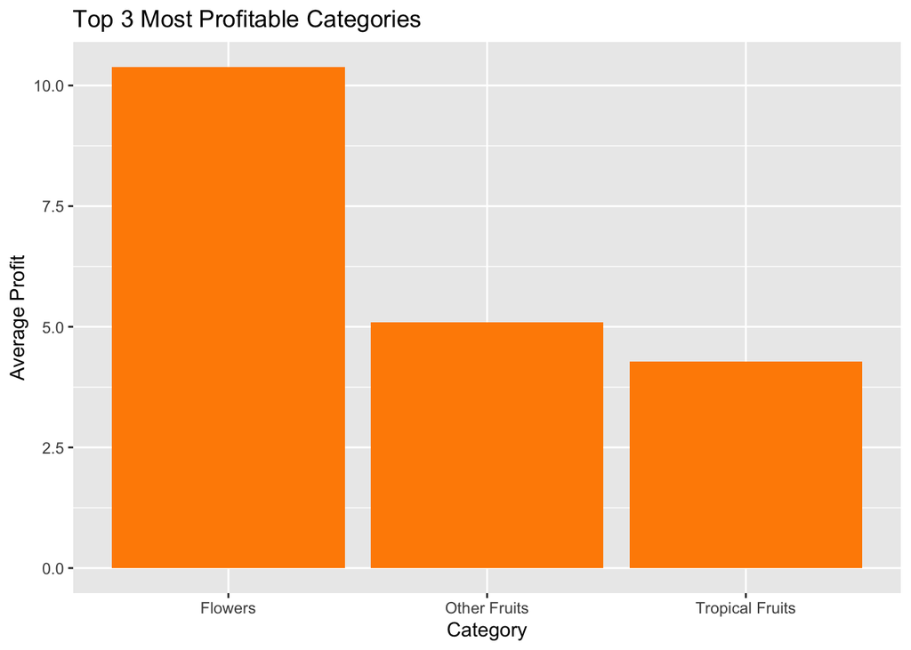

This bar chart shows that the three most profitable products are flowers, other fruits, and tropical fruits. Therefore, one of the most efficient ways to reduce losses and increase profits would be to sell more of these products that bring in the most revenue. This way the grocery stores could balance out the losses with an increased amount of profit.

## Top 3 Least Profitable Categories

The top 3 least profitable categories from the dataset are represented by the following bar graph:

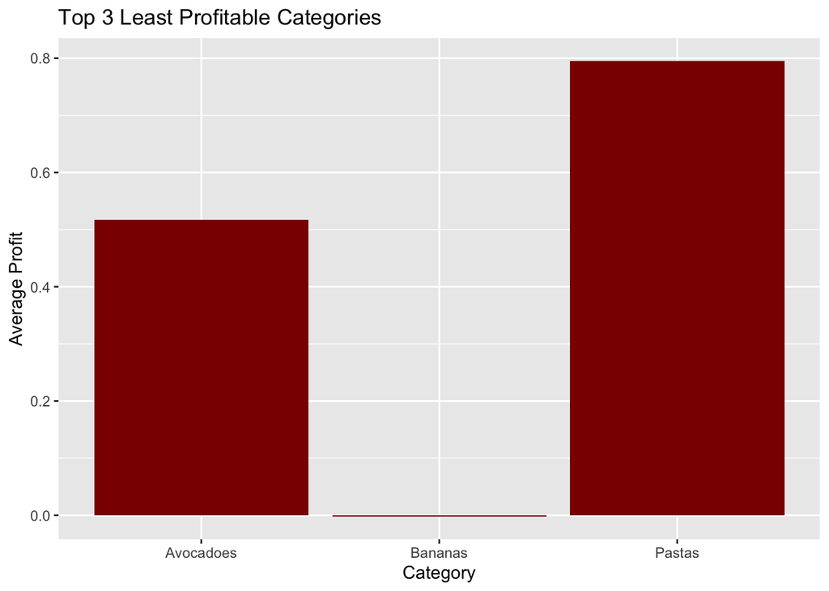

This bar chart shows that the three least profitable categories are Avocadoes, Bananas, and Pastas. Therefore, another efficient way to reduce losses is to decrease the number of units of each of these products purchased for selling. This way, the grocery stores would be able to still make a profit off of these items, while not having too much in stock to where they are not making enough profit. Another possible solution would be to strategically place these least profitable items towards the front of the grocery store and the most profitable items towards the back. Studies show that consumers often are more likely to buy products that they would otherwise not buy if they were easier to find. For more information on ideal store geography, refer to this [link](https://www.realsimple.com/food-recipes/shopping-storing/more-shopping-storing/grocery-store-layout).

| Categories | Average Unit Price Sell |
| --- | --- |
| markdown bag | 1.000000 |
| Pastas | 1.270892 |
| carrots | 1.596825 |
| Cut Fruits | 1.775133 |
| Melons | 1.789278 |
| Pumpkins | 1.990000 |
| Bananas | 2.009179 |
| Avocadoes | 2.193760 |
| Cut Veggies | 2.226083 |
| Bunch Vegies | 2.433894 |

| Categories | Average Unit Price Sell |
| --- | --- |
| coconut Products | 5.540008 |
| Lettuces | 6.404962 |
| trutaste | 6.777940 |
| Veggies | 7.411049 |
| Other Fruits | 8.042696 |
| Mushrooms | 8.549820 |
| Nuts | 9.140833 |
| Flowers | 9.217872 |
| Kalamata olives | 9.446476 |
| Chillies | 14.245755 |